# Clash Royale Analysis Project Report

Project Report for STAT 303-1 Fall 2025

Author

James Li

Published

December 8, 2025

Abstract

## 1) Inspiration

The dataset analyzed in this project comes from the mobile strategy game Clash Royale, specifically focusing on matches played at relatively high trophy levels. I chose this data because I am an active player of the game and have long been interested in understanding what actually drives success in competitive play. Within the Clash Royale community, trophies are often used as a proxy for player skill, yet this assumption has never been thoroughly examined with quantitative evidence.

This dataset provides a unique opportunity to investigate whether higher trophy counts truly reflect better performance, or whether other factors-such as deck composition, card choice, and strategic synergies-play a more significant role in determining match outcomes. The availability of card information allows for a detailed analysis of deck-building trends, enabling the exploration of whether specific cards or combinations provide structural advantages independent of player skill.

I consider this project valuable because it connects personal interest with a data-driven perspective on competitive game design and player behavior. Understanding what influences match outcomes is not only useful for players trying to optimize their decks, but also for developers aiming to maintain balance, fairness, and strategic diversity within the game’s evolving meta. By analyzing real matches from upper-ladder play-where players have access to most cards and generally exhibit high skill-the data offers a meaningful lens into how performance, strategy, and skill representation interact in a complex competitive environment.

## 2) Problem Statements

This project explores several research questions related to performance and strategy in Clash Royale:

1. Does a higher trophy count actually predict a higher win rate? In other words, does the ranking system accurately capture player skill, or do other variables better explain competitive success?
2. Which cards are most effective in terms of win rate, and are certain decks or combinations of cards consistently more successful than others?
3. Do specific card synergies (pairs or sets of cards used together) confer a measurable strategic advantage beyond individual card strength?
4. Is there a “meta bias” in the game, where certain cards appear more frequently at high trophy levels regardless of their objective performance? This addresses whether high-level players gravitate toward particular strategies even if they are not always optimal.

## 3) Data

The primary dataset used in this project was obtained from Kaggle:

- Dataset: Clash Royale Battles – Upper Ladder December 2021
- Author: Eric Xue
- URL: https://www.kaggle.com/datasets/nonrice/clash-royale-battles-upper-ladder-december-2021

This dataset contains 718,886 observations, where each observation represents a single 1v1 battle played in Clash Royale during December 2021 at the upper ladder, the high-trophy range of competitive play. The dataset focuses on matches where both players are operating in a competitive environment, which makes it ideal for examining patterns in strategic decision-making, card selection, and performance outcomes.

Each observation includes a set of variables describing both players’ characteristics and choices. The key information captured for each battle includes:

- The trophy count of each player prior to the match, representing their current ranking.
- The deck composition for each player, consisting of the eight cards used in that match (16 card columns total).
- The match outcome, indicating which player won.

In total, the dataset contains around 19 variables. The core structure includes:

- Numeric variables: Primarily trophy counts and outcome indicators. There are 3 main numeric variables in the original dataset: player 1 trophies, player 2 trophies, and match outcome.
- Categorical variables: Primarily all card identifiers. There are 16 card variables, corresponding to the eight cards used by each player in a match.

In addition to the battle dataset, a small supplementary dataset was used to map card IDs to card names and provide basic card attributes. This dataset contains 106 rows, each representing a unique card in the game. These variables were categorical and used to enhance interpretability, but not directly modeled.

For the purposes of this project, analysis primarily relied on the following variables:

- 3 numeric variables: player 1 trophies, player 2 trophies, match outcome
- 16 categorical variables: card identifiers for each player’s deck

In total, 19 variables from the dataset were used to conduct all analyses in this report. Additional metadata from the card list was used to attach descriptive labels but did not introduce new modeling variables.

## 4) Stakeholders

The findings of this project would be relevant to several groups within the Clash Royale community, each of whom could benefit from data-driven insights into gameplay and performance.

1. Clash Royale players: Competitive players, content creators, and casual players alike would be interested in understanding which strategies, cards, and deck compositions are most effective. Insights into the relationship between trophy level, card usage, and win rate could help players optimize their decks, make informed strategic decisions, and improve performance.
2. Supercell (the game developers): The results may provide valuable feedback on the state of the game’s competitive balance. Identifying which cards or combinations consistently outperform others-and whether high-level players converge on a narrow set of strategies-could help inform balancing decisions, card design, and efforts to maintain fair and diverse gameplay.
3. Competitive scene organizers and analysts: Esports commentators, analysts, or tournament organizers might use this information to understand the meta, evaluate balancing patches, or contextualize player performance during competitions.

## 5) Data Cleaning

### a) Cleaning - Question 1

For Question 1, I restricted the dataset to the variables directly needed for the analysis: the two players’ trophy counts (p1trophies, p2trophies) and the match outcome (outcome). From these, I later created derived variables such as the trophy difference between the players.

Missing values: After subsetting to these variables, I checked for missing values in p1trophies, p2trophies, and outcome. Any battle with a missing trophy count for either player or a missing outcome was removed from the Question 1 analysis. Since the number of such rows was very small relative to the full dataset, dropping them is preferable to trying to “guess” trophies or outcomes that were never recorded. There were no missing values for any variable

Duplicate Values: Despite not finding any missing values, there were 384,188 duplicate rows (matches) in the dataset. These duplicates likely arose from repeated logging of the same battle entry and would artificially inflate win rates or usage counts if left in place. To avoid biased estimates and ensure each match contributed only once to the analysis, I removed all exact duplicates while preserving the first occurrence. After deduplication, the dataset accurately reflected the true number of unique battles and provided a reliable foundation for subsequent modeling and visualization.

Outliers in numeric variables: For Q1, the key numeric variables are the trophy counts of the two players. To assess outliers, I combined the trophy values for both players into one distribution and computed the first quartile (Q1), third quartile (Q3), and the interquartile range (IQR = Q3 − Q1). Using the standard 1.5×IQR rule, I identified trophy values below Q1 − 1.5×IQR or above Q3 + 1.5×IQR as outliers.

This flagged a set of unusually low or unusually high trophy values. These represent, respectively, the lowest- and highest-ranked matches within the upper-ladder dataset.

Treatment of outliers and rationale: I did not remove these trophy outliers for Q1. The reason is that, in this context, extreme trophy values are not data errors; they correspond to legitimately very low or very high ranked players within the sample. Removing the highest and lowest trophy matches would remove exactly the cases where we expect the strongest differences.

Categorical variables and categories: For Q1, there are no true categorical variables in the analysis; outcome is treated as a binary numeric variable, coded as 1 if player 1 won and 0 if player 1 lost. There are therefore only two “categories” for outcome (win/loss), and both are essential. No category-level filtering or merging was needed.

Incorrect or invalid values: I checked for incorrect values in the variables used:

- ‘outcome’ was restricted to 0 or 1. Any observations that did not satisfy this (if present) would have been dropped as invalid.
- Trophy counts were non-negative and within a plausible range for upper-ladder Clash Royale play, so no trophy values were corrected or removed.

After these checks, the final Q1 dataset contained only valid, interpretable values for trophy counts and outcomes.

Additional cleaning decision (player symmetry): One additional step for Q1 was to randomly relabel player 1 and player 2 on a per-game basis. Since the underlying game does not inherently favor “player 1” as an identity, this randomization prevents any systematic bias tied to how players were labeled in the raw data (for example, if the dataset always listed the higher-trophy player as p1, or always listed the first player to play a card as p1). After relabeling, the analysis is based on a symmetric comparison of “higher vs. lower trophy player,” not a hard-coded “player 1 vs. player 2” distinction. This makes the logistic regression and trophy-difference analyses more interpretable and fair.

### b) Cleaning - Question 2

For Question 2, the goal was to analyze card-level performance by examining how often individual cards appear in decks and how their usage relates to win rate. To support this, I transformed the original battle-level dataset into a card-level format where each row represents a single card appearance in a match. This required multiple data cleaning and restructuring steps.

Missing values: The analysis required card identifiers for all eight cards used by each player in every match, trophy counts, as well as the match outcome. I checked for missing values. There were no missing values.

Imputation strategy and rationale: There were no missing values.

Outliers in numeric variables: The card-level dataset included trophy counts in addition to the binary outcome variable. I identified extreme trophy values using the IQR method, but these outliers represent legitimate matches involving very high- or very low-ranked players. Since the goal was to analyze card performance across the full competitive range, I chose not to remove trophy outliers, consistent with the approach used in Question 1. Retaining them preserves meaningful variation in player skill and prevents bias toward mid-range matches.

Handling incorrect or invalid values: I verified that deck_outcome only contained values of 0 or 1; any rows that did not meet this criterion would have been removed, but no invalid outcomes were present after initial cleaning. Card identifiers were checked for numeric validity prior to merging with card metadata; there were no invalid values.

Categorical variables and number of categories: The main categorical variable for Q2 is the card identifier, representing which card appears in each deck. After merging with the card metadata file, each card was associated with a readable card name. There were 106 unique cards in the dataset, matching the number of cards available in the game at the time the data was collected.

Handling rare or uninformative categories: There were no categories (cards) that were uninformative or not useful.

Restructuring decisions: To perform card-level analysis, I reshaped the data from a match-level structure to a card-level structure:

- I separated decks for both players.
- I encoded the outcome from each player’s perspective (win/loss).
- I combined the decks into a unified dataset.
- I reshaped the data from wide format (8 card columns) to long format (one row per card appearance).

This produced a dataset where each row corresponds to a card appearance in a match, with a binary outcome indicating whether that appearance was associated with a win.

Preserving interpretability: I merged the analysis dataset with a card metadata file mapping card IDs to card names. This step was necessary to ensure that results and visualizations were interpretable and could be described meaningfully in written analysis.

### c) Cleaning - Question 3

Question 3 analyzes card synergies by identifying how pairs of cards tend to perform together in decks. This required transforming the dataset from a card-level structure into a pair-level structure, where each observation represents a co-occurring pair of cards from the same deck, along with the outcome of that deck.

Missing values: To perform pair-level analysis, I focused on the card identifiers and outcome variable from each match. There were no rows with missing card IDs or missing outcomes.

Outliers in numeric variables: The pair-level dataset includes trophy counts for each deck, enabling analysis of how synergies vary by player skill. I identified extreme trophy values using the IQR method. However, these reflect legitimate matches involving very high- or very low-ranked players and are important for capturing variation in competitive behavior. As with previous questions, I kept trophy outliers to maintain the full trophy range and avoid biasing results toward mid-skill players.

Incorrect or invalid values: Pairs were generated only from valid card identifiers, and the outcome variable was verified to contain only 0/1 values. No negative, out-of-range, or duplicate outcome values were found.

Categorical variables and number of categories. The main categorical variables for Q3 are card identifiers and card pairs. There are roughly 100 unique cards, which produce a very large number of possible pairs. To make the analysis tractable and meaningful, I limited the analysis to pairs that occurred at least once in the dataset. Pairs that never occurred, or occurred only extremely rarely, were excluded because they cannot produce stable estimates and would introduce noise into the results.

Handling rare or uninformative categories: Although some very rare card pairs exist, the vast majority of card combinations occur quite frequently in this dataset. After generating all valid pairs, I applied a minimum-usage threshold (e.g., at least 100 appearances) to ensure that estimated win rates were based on sufficient data. This filter was not very restrictive: about 94.66% of all observed pairs were retained. This step mainly removed extremely rare combinations, reducing noise while preserving almost all of the meaningful synergies present in the meta.

Restructuring decisions: To create the pair-level dataset, I:

- Extracted each player’s deck.
- Computed all unique unordered card pairs from each deck.
- Attached the deck’s outcome to each pair.
- Combined player 1 and player 2 data into a unified table.

This reshaping process resulted in a dataset where each row represents a card pair and its associated match outcome. Because each deck contains 8 cards, each match produces 28 unique pairs, which explains why the pair dataset is substantially larger than the original deck-level data.

Final dataset characteristics: After cleaning and filtering, the Q3 dataset contains:

- Valid card pairs that occurred at least 100 times in real matches,
- Associated deck outcomes for each pair appearance, and
- Trophy counts reflecting the competitive environment of each match.

This dataset was then used to estimate pair-level win rates and identify card synergies that consistently outperform baseline expectations.

### d) Cleaning - Question 4

Question 4 examines how card usage changes across different trophy ranges, so the core variables are the card identifiers and the player’s trophy count for each card appearance. The starting point for this question was the card-level dataset (card_df), where each row represents one card used in one deck in one match, along with the associated player trophies.

Missing values: For Q4, I first restricted the data to the columns needed: the card identifiers (card) and the player’s trophy count (trophies). I then ensured trophies were numeric. There were no missing values. No values were imputed.

Outliers in numeric variables and how they were handled: The main numeric variable in Question 4 is the continuous trophy count. I examined outliers using the interquartile range (IQR) method by calculating Q1, Q3, and IQR for trophy values, and identifying observations outside the standard 1.5·IQR bounds. These outliers represent extremely low- or high-ranked players within the upper-ladder sample.

Because the purpose of Q4 is to compare card usage patterns across trophy levels, and because outliers reflect legitimate matches within the competitive environment, I retained all trophy values, including those flagged as outliers. Removing these cases would artificially shrink the range of trophy levels represented and potentially distort usage rates in the highest and lowest bands. Keeping them ensures that the full diversity of competitive contexts is preserved when analyzing how card usage varies by player skill level.

- < 5000 trophies
- 5000–6000
- 6000–7000
- 7000–8000
- 8000+

These were stored in a categorical variable trophy_band. This step is crucial because all usage rates in Q4 are defined within these bands.

Categorical variables and categories: The key categorical variables for Q4 are:

- card: the card identifier (later mapped to card names in other sections), and
- trophy_band: the categorical representation of the player’s trophy level.

Originally, there are 106 distinct cards in the dataset. The trophy band variable has exactly 5 categories corresponding to the ranges listed above.

Handling rare or uninformative categories: In Question 4, the primary categorical variable is the card identifier. While some cards appear far less frequently than others, I chose not to exclude low-usage cards from the analysis. This decision was made because the objective of Q4 is to describe how card usage varies across trophy levels, rather than to estimate precise performance metrics or win rates. Even cards with relatively low overall usage contribute meaningfully to understanding which strategies or archetypes are adopted at different skill levels, especially if they are concentrated in specific trophy bands. Retaining all cards preserves the full diversity of strategic options available to players and avoids biasing the analysis toward only the most popular or widely used cards.

Incorrect or invalid values: After conversion, all remaining trophies values were non-negative and fell within a plausible upper-ladder range for Clash Royale, and all card values corresponded to valid card identifiers in the card list. No incorrect or impossible values (such as negative trophies) were observed in the variables used for Q4 after the initial cleaning steps.

Final analysis dataset for Q4: The final clash_q4 dataset used for Question 4 therefore consists of:

- One row per card per trophy band,
- A cleaned, in-range trophy value, and
- An associated trophy_band category

This cleaned structure supports reliable estimates of card usage percentages across trophy bands, which is the focus of the Q4 analysis.

## 6) Data Analysis

### a) Analysis 1

#### Methodology

To answer this question, I focused on three core variables from each battle:

- ‘p1trophies’ and ‘p2trophies’: the pre-match trophy counts for player 1 and player 2
- outcome: a binary variable equal to 1 if player 1 won and 0 if player 1 lost

The analysis proceeded in four stages:

1. Check matchmaking symmetry using an overlaid histogram of p1trophies and p2trophies.

   Reasoning: This non-parametric view shows the raw pattern in the data without assuming any specific model.
4. Logistic regression model with trophy_diff as the predictor and outcome as the binary response, plus evaluation of the model using AUC (area under the ROC curve) and classification accuracy at a 0.5 decision threshold.

   Reasoning: Logistic regression provides a smooth estimate of how the probability of winning changes with trophy difference and lets us quantify predictive performance beyond simple visuals.

#### Visual and Numeric Results

1. Overlaid histogram of player 1 and player 2 trophies

The first figure shows two histograms overlaid: one for p1trophies and one for p2trophies. Visually, the two distributions nearly overlap across the entire range, indicating that the matchmaking system generally pairs players with similar trophy counts. There is no obvious systematic shift suggesting that one player slot (player 1 vs player 2) tends to have higher trophies.

- Both distributions are concentrated in the upper-ladder trophy range expected from the Kaggle description.
- Summary statistics (means/medians) for p1trophies and p2trophies are very close, consistent with balanced matchmaking.

This justifies treating the two players symmetrically and focusing on relative difference (trophy_diff) rather than any inherent advantage for “player 1.”

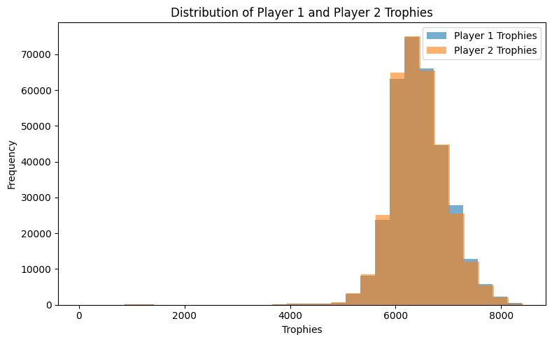

```
SUMMARY STATISTICS: Player 1 trophies
count    334698.000000
mean       6451.456459
std         549.190248
min          30.000000
25%        6103.000000
50%        6418.000000
75%        6781.000000
max        8399.000000
Name: p1trophies, dtype: float64

SUMMARY STATISTICS: Player 2 trophies
count    334698.000000
mean       6452.299831
std         548.038174
min          27.000000
25%        6103.000000
50%        6418.000000
75%        6781.000000
max        8424.000000
Name: p2trophies, dtype: float64

SUMMARY STATISTICS: Trophy Difference (P1 - P2)
count    334698.000000
mean         -0.843372
std         439.409024
min       -6669.000000
25%         -32.000000
50%           0.000000
75%          32.000000
max        7007.000000
Name: trophy_diff, dtype: float64

OVERALL WIN RATE
Player 1 win rate: 0.499
Player 1 wins: 167121
Player 2 wins: 167577
```

2. Win rate vs trophy difference (binned plot)

To visualize how trophy difference affects win rate, I:

- Binned trophy_diff into equally spaced intervals (e.g., 30-trophy bins).
- For each bin, computed the mean of outcome (i.e., the win rate for player 1 in that bin).
- Plotted bin midpoint vs. win rate (%), with a horizontal line at 50% as the baseline.

This binned plot shows a clear but moderate pattern:

- Around trophy_diff ≈ 0, the win rate for player 1 is very close to 50%, as expected when both players have similar trophies.
- As trophy_diff becomes positive (player 1 has more trophies), the win rate rises above 50%.
- As trophy_diff becomes negative, the win rate falls below 50%.

The curve increases gradually rather than sharply, indicating that trophy difference does matter, but its effect is incremental, not overwhelming. Having more trophies gives an advantage, but does not guarantee a win.

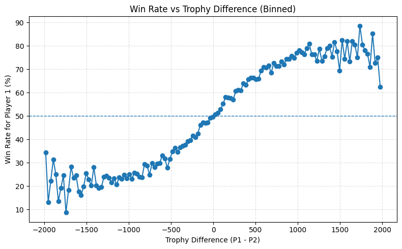

[output not shown]

3. Logistic regression and model performance

To quantify this relationship, I fit a logistic regression model:

- Response: outcome (1 = player 1 win, 0 = player 1 loss)
- Predictor: a scaled trophy difference, so that a one-unit change corresponds to a 30-trophy difference between players.

Key points from the model:

- The estimated coefficient is positive, meaning that as player 1’s trophy advantage increases, the probability of winning also increases.
- In odds-ratio terms, this corresponds to an odds ratio greater than 1 per 30-trophy increase, i.e., each extra 30 trophies slightly increases the odds that the higher-trophy player wins.

To evaluate predictive performance, I used two metrics:

- AUC (Area Under the ROC Curve)
  - The AUC for the 30-trophy model is 0.593.
  - Interpretation:
    - An AUC of 0.5 corresponds to random guessing.
    - An AUC of 1.0 corresponds to perfect prediction.
    - An AUC of 0.593 indicates the model is better than random, but not highly predictive.
    - In practical terms, if you randomly pick one game where the higher-trophy player won and one where they lost, the model will assign a higher predicted probability to the win-game about 59.3% of the time.
- Accuracy at the 0.5 threshold
  - Using the rule “predict win if the model’s predicted probability > 0.5,” the accuracy is 0.554 (55.4%).
  - Compared to a naive baseline of 50% (always guessing at random), the model is only about 5.4 percentage points better.
  - This means that trophy difference alone correctly predicts just over half of match outcomes, but still gets a large fraction of games wrong.

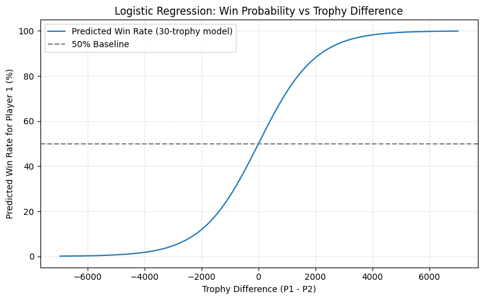

```python
from sklearn.metrics import roc_auc_score
import numpy as np
import matplotlib.pyplot as plt

#display(clash_q1.head())
# Predict probabilities for each match

# Rebuild X in case it's not in scope
X = clash_q1[["trophy_diff_30"]].values  # shape (n,1)

# Predicted probability that Player 1 wins
clash_q1["pred_prob_30"] = model.predict_proba(X)[:, 1]


# Plot predicted probability curve vs trophy_diff

# Range of actual trophy differences
x_vals = np.linspace(clash_q1["trophy_diff"].min(),
                     clash_q1["trophy_diff"].max(), 200)

# Convert to 30-trophy units for the model
x_vals_30 = (x_vals / 30).reshape(-1, 1)

# Predicted probabilities across this range
probs_curve = model.predict_proba(x_vals_30)[:, 1]

plt.figure(figsize=(8, 5))
plt.plot(x_vals, probs_curve * 100, label="Predicted Win Rate (30-trophy model)")
plt.axhline(50, linestyle="--", color="gray", label="50% Baseline")

plt.xlabel("Trophy Difference (P1 - P2)")
plt.ylabel("Predicted Win Rate for Player 1 (%)")
plt.title("Logistic Regression: Win Probability vs Trophy Difference")
plt.grid(True, linestyle="--", alpha=0.4)
plt.legend()
plt.tight_layout()
plt.show()
```

```python
import numpy as np
from sklearn.linear_model import LogisticRegression

# Create scaled predictor
# 1 unit = 30 trophies
clash_q1["trophy_diff_30"] = clash_q1["trophy_diff"] / 30

# Predictor matrix (2D)
X = clash_q1[["trophy_diff_30"]].values  # shape (n,1)

# Outcome vector (1D)
y = clash_q1["outcome"].values           # shape (n,)

# Fit logistic regression
# Use lbfgs solver (had to google)
model = LogisticRegression(solver="lbfgs", C=1e6)
model.fit(X, y)

# Coefficient + odds ratio
coef = model.coef_[0][0]             # slope
intercept = model.intercept_[0]      # intercept
odds_ratio = np.exp(coef)

print("\nLOGISTIC REGRESSION RESULTS")
print(f"Intercept: {intercept:.4f}")
print(f"Coefficient (per 30 trophies): {coef:.4f}")
print(f"Odds Ratio (per 30 trophies): {odds_ratio:.4f}")

# Compute AUC (discrimination ability)

y_true = clash_q1["outcome"].values
auc = roc_auc_score(y_true, clash_q1["pred_prob_30"])
print(f"\nAUC (using 30-trophy model): {auc:.3f}")

# Compute accuracy at threshold 0.5

clash_q1["pred_class_30"] = (clash_q1["pred_prob_30"] > 0.5).astype(int)
accuracy = (clash_q1["pred_class_30"] == clash_q1["outcome"]).mean()
print(f"Accuracy at 0.5 threshold: {accuracy:.3f}")
```

```
LOGISTIC REGRESSION RESULTS
Intercept: -0.0028
Coefficient (per 30 trophies): 0.0301
Odds Ratio (per 30 trophies): 1.0305

AUC (using 30-trophy model): 0.593
Accuracy at 0.5 threshold: 0.554
```

#### Answer to Question 1 and Interpretation

Based on the visual and numeric analyses, the answer is: Yes, but only weakly.

Key points:

- The trophy distributions for player 1 and player 2 are nearly identical, confirming symmetric matchmaking and no systemic labeling bias.
- The distribution of trophy differences is centered near zero, with most matches involving relatively small trophy gaps.
  - The binned plot of win rate vs. trophy difference shows that:
  - When trophy counts are equal, the win rate is essentially 50–50.
- As one player’s trophy advantage grows, their win rate increases gradually above 50%, and the lower-trophy player’s win rate correspondingly decreases.
- The logistic regression model quantifies this pattern:
  - A positive coefficient and odds ratio > 1 per 30 trophies confirm that more trophies → higher chance of winning.
  - However, the AUC of 0.593 and accuracy of 0.554 indicate that trophy difference alone is a weak predictor of match outcome.

Real-life interpretation:

- Trophies capture some aspect of player skill or long-run performance, and having more trophies than your opponent does give you an edge.
- But the effect size is modest: even with a trophy advantage, you are far from guaranteed to win. In practical play, this suggests that factors like deck composition, card synergy, playstyle, and in-game decision-making account for a large portion of the outcome variance.
- From a game design perspective, this is actually desirable: the ranking system has predictive power (higher-ranked players win more often), but outcomes are not predetermined, preserving the importance of strategy and execution in each individual match.

### b) Analysis 2

#### Methodology

For Question 2, the goal is to estimate how individual cards perform in terms of win rate and how that performance relates to how often they are used.

To do this, I first restructured the data to a card-level format:

- Each row in card_df represents one card appearance in a deck for a single match.
- The variable deck_outcome is equal to 1 if the deck containing that card won the match, and 0 if it lost.
- The column card identifies which specific card it is.

This structure lets me treat deck_outcome as a binary outcome “attached” to each card appearance.

For each card, I then:

- Grouped by card and computed:
  - usage = number of times the card appears in decks
  - win_rate = mean of deck_outcome (proportion of wins)
- Computed 95% confidence intervals (CIs) for each win rate using the normal approximation to the binomial distribution.
- Created two main visualizations:
  - A bar plot of win rate by card (with 95% CIs), sorted alphabetically and zoomed to 40–60% to highlight meaningful differences around 50%.
  - A scatter plot of win rate vs usage, with error bars and labels for the most-used cards, to explore whether popular cards are actually strong.

#### Visual and Numeric Results

The first figure shows each card’s win rate as a bar, with 95% confidence intervals as error bars. The x-axis lists cards alphabetically, and the y-axis shows win rate (%), zoomed to 40–60%. A red dashed line at 50% marks the “perfectly balanced” point.

What the plot shows:

- Most cards cluster reasonably close to 50% win rate, reflecting that the game is broadly balanced at the card level.
- Some cards sit noticeably above the 50% baseline, with win rates whose confidence intervals do not overlap 50%. These are candidates for strong (possibly overtuned) cards.
- A smaller set of cards sits below 50%, with confidence intervals clearly under the baseline, suggesting underperforming cards.

From the numeric summaries:

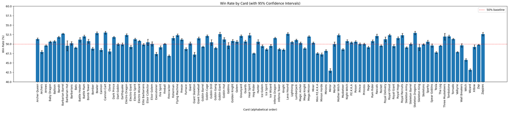

```
Top 10 Highest Win-Rate Cards
```

|  | card | win_rate | usage | ci_lower | ci_upper |
| --- | --- | --- | --- | --- | --- |
| 16 | Cannon Cart | 0.530039 | 61037 | 0.526080 | 0.533999 |
| 89 | Skeleton Dragons | 0.529267 | 42334 | 0.524512 | 0.534022 |
| 14 | Bowler | 0.528559 | 66651 | 0.524769 | 0.532349 |
| 6 | Barbarian Barrel | 0.527035 | 249380 | 0.525075 | 0.528995 |
| 59 | Lava Hound | 0.526596 | 75386 | 0.523032 | 0.530161 |
| 105 | Zappies | 0.526117 | 45047 | 0.521506 | 0.530728 |
| 43 | Goblin Giant | 0.526084 | 32185 | 0.520628 | 0.531539 |
| 21 | Electro Dragon | 0.523644 | 77566 | 0.520130 | 0.527159 |
| 86 | Royal Recruits | 0.523208 | 39233 | 0.518265 | 0.528150 |
| 83 | Royal Ghost | 0.523133 | 101024 | 0.520053 | 0.526213 |

```
Bottom 10 Lowest Win-Rate Cards
```

|  | card | win_rate | usage | ci_lower | ci_upper |
| --- | --- | --- | --- | --- | --- |
| 69 | Mirror | 0.429726 | 33035 | 0.424388 | 0.435064 |
| 102 | Wizard | 0.431503 | 104706 | 0.428503 | 0.434503 |
| 101 | Witch | 0.458051 | 86820 | 0.454737 | 0.461365 |
| 31 | Firecracker | 0.468717 | 117924 | 0.465869 | 0.471565 |
| 37 | Giant Skeleton | 0.472090 | 28556 | 0.466300 | 0.477880 |
| 67 | Minion Horde | 0.472375 | 54751 | 0.468193 | 0.476557 |
| 28 | Executioner | 0.473547 | 50939 | 0.469211 | 0.477883 |
| 66 | Mini P.E.K.K.A | 0.474834 | 140112 | 0.472220 | 0.477449 |
| 51 | Hog Rider | 0.474845 | 240127 | 0.472847 | 0.476842 |
| 94 | Tesla | 0.477595 | 153201 | 0.475094 | 0.480096 |

```
10 Cards Closest to 50% Win Rate (Balanced Cards)
```

|  | card | win_rate | usage | ci_lower | ci_upper |
| --- | --- | --- | --- | --- | --- |
| 77 | Princess | 0.500076 | 151881 | 0.497561 | 0.502590 |
| 88 | Skeleton Barrel | 0.499908 | 92501 | 0.496686 | 0.503130 |
| 76 | Prince | 0.500127 | 126102 | 0.497367 | 0.502887 |
| 70 | Mortar | 0.499852 | 30395 | 0.494231 | 0.505473 |
| 27 | Elixir Golem | 0.500467 | 32154 | 0.495001 | 0.505932 |
| 30 | Fireball | 0.500499 | 452233 | 0.499041 | 0.501956 |
| 19 | Dart Goblin | 0.499424 | 108475 | 0.496448 | 0.502399 |
| 20 | Earthquake | 0.498997 | 62820 | 0.495087 | 0.502907 |
| 91 | Skeletons | 0.498872 | 214189 | 0.496755 | 0.500990 |
| 36 | Giant | 0.501338 | 63147 | 0.497438 | 0.505238 |

The second figure plots usage (x-axis) versus win rate (%) (y-axis) for each card, using only cards with at least a modest amount of data (e.g., usage ≥ 100). Each point is a card:

- x = number of decks containing that card
- y = estimated win rate (%) for that card
- vertical error bars = 95% confidence intervals
- a horizontal red dashed line at 50% again marks the baseline.

To avoid clutter, only cards with very high usage (e.g., usage > 200,000) are labeled by name on the plot. These are the “meta staples” that appear in a huge number of decks.

What the plot and numeric outputs show:

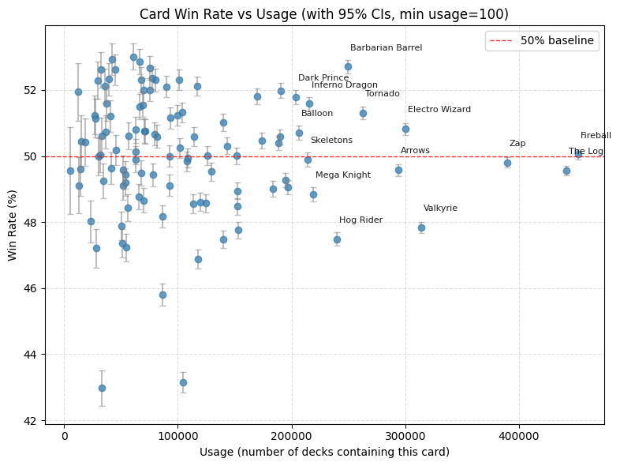

```
Cards with Usage > 200,000 (Labeled on Plot)
```

|  | card | usage | win_rate | ci_lower | ci_upper |
| --- | --- | --- | --- | --- | --- |
| 2 | Arrows | 293831 | 0.495809 | 0.494001 | 0.497617 |
| 4 | Balloon | 206473 | 0.507161 | 0.505004 | 0.509317 |
| 6 | Barbarian Barrel | 249380 | 0.527035 | 0.525075 | 0.528995 |
| 18 | Dark Prince | 203831 | 0.517875 | 0.515706 | 0.520044 |
| 24 | Electro Wizard | 299980 | 0.508164 | 0.506375 | 0.509953 |
| 30 | Fireball | 452233 | 0.500499 | 0.499041 | 0.501956 |
| 51 | Hog Rider | 240127 | 0.474845 | 0.472847 | 0.476842 |
| 56 | Inferno Dragon | 215819 | 0.515798 | 0.513690 | 0.517906 |
| 63 | Mega Knight | 218961 | 0.488448 | 0.486354 | 0.490541 |
| 91 | Skeletons | 214189 | 0.498872 | 0.496755 | 0.500990 |
| 95 | The Log | 441936 | 0.495569 | 0.494095 | 0.497044 |
| 98 | Tornado | 262917 | 0.513067 | 0.511156 | 0.514977 |
| 99 | Valkyrie | 314353 | 0.478414 | 0.476668 | 0.480161 |
| 104 | Zap | 389347 | 0.498047 | 0.496476 | 0.499617 |

```
Top 10 Highest Win-Rate Cards (with ≥100 usage)
```

|  | card | win_rate | usage | ci_lower | ci_upper |
| --- | --- | --- | --- | --- | --- |
| 16 | Cannon Cart | 0.530039 | 61037 | 0.526080 | 0.533999 |
| 89 | Skeleton Dragons | 0.529267 | 42334 | 0.524512 | 0.534022 |
| 14 | Bowler | 0.528559 | 66651 | 0.524769 | 0.532349 |
| 6 | Barbarian Barrel | 0.527035 | 249380 | 0.525075 | 0.528995 |
| 59 | Lava Hound | 0.526596 | 75386 | 0.523032 | 0.530161 |
| 105 | Zappies | 0.526117 | 45047 | 0.521506 | 0.530728 |
| 43 | Goblin Giant | 0.526084 | 32185 | 0.520628 | 0.531539 |
| 21 | Electro Dragon | 0.523644 | 77566 | 0.520130 | 0.527159 |
| 86 | Royal Recruits | 0.523208 | 39233 | 0.518265 | 0.528150 |
| 83 | Royal Ghost | 0.523133 | 101024 | 0.520053 | 0.526213 |

#### Answer to Question 2 and Interpretation

- The card-level win rate analysis shows real but modest differences across cards.
- Most cards have win rates clustered very close to 50%, with only moderate variation around that baseline.
- The overall distribution is centered near 0.50, indicating strong general balance across the card pool.
- Only a small subset of cards show clearly above- or below-average win rates once usage counts and confidence intervals are considered.
- The win rate vs. usage scatter plot provides additional insight:
  - There is only a weak relationship between card popularity and win rate.
  - Many of the most-used cards still perform close to 50%, suggesting they are chosen for versatility or meta preference rather than raw strength.
  - Some moderately used cards achieve noticeably higher win rates, pointing to potentially strong but less widely adopted options.
  - Confidence intervals are tight for high-usage cards (stable estimates) but wider for rarely used cards, making extreme values for low-usage cards less reliable.

### c) Analysis 3

#### Methodology

The goal of Question 3 is to move beyond individual cards and investigate whether pairs of cards used together show evidence of synergy. The unit of analysis shifts from “card appearance” to “card pair within a deck.”

#### Visual and Numeric Results

The first figure displays the top 20 card pairs by win rate, among pairs that met the usage threshold. For each pair, the plot shows:

- The mean win rate (bar height, in %)
- A 95% confidence interval (error bars)
- A horizontal line at 50% as the baseline (a fair coin).

From the corresponding numeric summary (e.g., sorted df_pairs table):

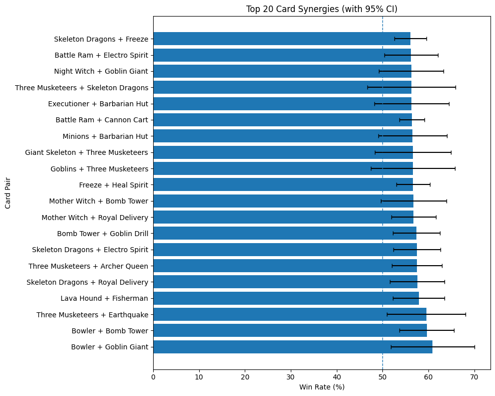

This scatter plot answers a different question than the first figure:

- Do the most popular pairs also have the highest win rates?
- Or are there underused but strong synergies lurking in the data?

From the numeric outputs that accompany this figure:

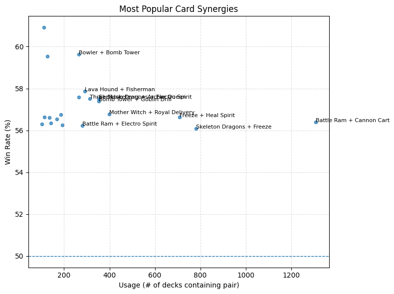

|  | cardA | cardB | cardA_name | cardB_name | pair_label | usage | win_rate | ci_lower | ci_upper |
| --- | --- | --- | --- | --- | --- | --- | --- | --- | --- |
| 0 | 34 | 60 | Bowler | Goblin Giant | Bowler + Goblin Giant | 110 | 0.609091 | 0.517903 | 0.700279 |
| 1 | 34 | 78 | Bowler | Bomb Tower | Bowler + Bomb Tower | 265 | 0.596226 | 0.537151 | 0.655302 |
| 2 | 28 | 101 | Three Musketeers | Earthquake | Three Musketeers + Earthquake | 126 | 0.595238 | 0.509531 | 0.680945 |
| 3 | 29 | 61 | Lava Hound | Fisherman | Lava Hound + Fisherman | 292 | 0.578767 | 0.522133 | 0.635401 |
| 4 | 70 | 105 | Skeleton Dragons | Royal Delivery | Skeleton Dragons + Royal Delivery | 264 | 0.575758 | 0.516139 | 0.635376 |
| 5 | 28 | 68 | Three Musketeers | Archer Queen | Three Musketeers + Archer Queen | 313 | 0.575080 | 0.520315 | 0.629845 |
| 6 | 70 | 72 | Skeleton Dragons | Electro Spirit | Skeleton Dragons + Electro Spirit | 353 | 0.575071 | 0.523502 | 0.626640 |
| 7 | 78 | 86 | Bomb Tower | Goblin Drill | Bomb Tower + Goblin Drill | 352 | 0.573864 | 0.522203 | 0.625525 |
| 8 | 71 | 105 | Mother Witch | Royal Delivery | Mother Witch + Royal Delivery | 398 | 0.567839 | 0.519170 | 0.616508 |
| 9 | 71 | 78 | Mother Witch | Bomb Tower | Mother Witch + Bomb Tower | 185 | 0.567568 | 0.496177 | 0.638958 |
| 10 | 92 | 103 | Freeze | Heal Spirit | Freeze + Heal Spirit | 708 | 0.566384 | 0.529880 | 0.602889 |
| 11 | 2 | 28 | Goblins | Three Musketeers | Goblins + Three Musketeers | 113 | 0.566372 | 0.474997 | 0.657746 |
| 12 | 20 | 28 | Giant Skeleton | Three Musketeers | Giant Skeleton + Three Musketeers | 136 | 0.566176 | 0.482881 | 0.649471 |
| 13 | 5 | 79 | Minions | Barbarian Hut | Minions + Barbarian Hut | 168 | 0.565476 | 0.490519 | 0.640434 |
| 14 | 36 | 54 | Battle Ram | Cannon Cart | Battle Ram + Cannon Cart | 1307 | 0.563887 | 0.537002 | 0.590772 |
| 15 | 45 | 79 | Executioner | Barbarian Hut | Executioner + Barbarian Hut | 142 | 0.563380 | 0.481804 | 0.644957 |
| 16 | 28 | 70 | Three Musketeers | Skeleton Dragons | Three Musketeers + Skeleton Dragons | 103 | 0.563107 | 0.467317 | 0.658897 |
| 17 | 48 | 60 | Night Witch | Goblin Giant | Night Witch + Goblin Giant | 192 | 0.562500 | 0.492329 | 0.632671 |
| 18 | 36 | 72 | Battle Ram | Electro Spirit | Battle Ram + Electro Spirit | 281 | 0.562278 | 0.504271 | 0.620284 |
| 19 | 70 | 92 | Skeleton Dragons | Freeze | Skeleton Dragons + Freeze | 781 | 0.560819 | 0.526013 | 0.595626 |

#### Answer to Question 3 and Interpretation

Based on the pair-level analysis, the answer is:

- Yes – many card pairs show clear, repeatable synergy, and some combinations are significantly stronger than the baseline deck.

Key points:

- For players, this suggests that thinking in terms of card combinations, not just single-card strength, is important. Adding a strong synergy pair to a deck can shift its win rate by several percentage points.
- For game balance and design, the presence of consistently high-performing pairs may be worth monitoring. If certain card combos dominate across a variety of decks, they can reduce meta diversity and push the game toward a smaller set of viable strategies.
- For deck-building strategy, the results support the idea that effective decks are built around core synergies rather than just plugging together “good cards.”

### d) Analysis 4

#### Methodology

For Question 4, the goal is not win rate, but popularity across skill levels:

- How does card usage change as we move from lower to higher trophy ranges?

To study this, I worked with the card-level dataset clash_q4, where each row represents one card appearance in one deck and includes:

- ‘card’: the card name
- ‘trophies’: the player’s trophy count for that match
- ‘trophy_band’: a categorical label for the trophy range
1. Define trophy bands

I converted continuous trophies into ladder “bands” using fixed breaks:

- < 5000
- 5000–6000
- 6000–7000
- 7000–8000
- 8000+

These bands are saved as trophy_band and are used for all Q4 summaries.

2. Compute card usage by band

For each combination of card and trophy band, I computed:

- ‘usage_count’: number of times that card appears in that band

Then, for each band, I also computed:

- ‘total_in_band’: total number of card appearances (across all cards)

I then pivoted this into a table:

- Rows: cards
- Columns: trophy bands
- Values: usage_pct (0–1)

This table is usage_pivot.

3. Summarize low-vs-high usage per card

For each card, I extracted:

- ‘usage_low’ = usage percentage in the lowest trophy band
- ‘usage_high’ = usage percentage in the highest trophy band
- ‘delta_usage’ = usage_high − usage_low

These give, for each card:

- How common is it at the top of the ladder?
- Does its usage increase or decrease with trophies?

I then used these to derive several views:

- Top meta cards: cards sorted by ‘usage_high’ (most common in 8000+)
- Risers: cards with large positive delta_usage
- Fallers: cards with large negative ‘delta_usage’
- Stable staples: cards with high usage but small ‘delta_usage’ (used everywhere)
4. Visualization strategy

I focused on two main visualizations:

- Bar chart of top meta cards in the highest trophy band
  - Shows which cards dominate the highest ladder range.
- Heatmap or line plots of usage across bands for those top cards
  - Shows whether those cards spike only at high trophies, or are consistently popular.

#### Visual and Numeric Results

The first figure is a horizontal bar chart using top_meta, showing:

- x-axis: usage percentage in the highest trophy band (e.g., 8k+)
- y-axis: card names (sorted from most to least used in that band)

This figure directly answers:

- “Which cards are most common in top-ladder decks?”

Supporting numeric outputs (from the summary_q4 / usage_pivot tables) include:

- For each of these top cards:
  - usage_high: how often they appear at high trophies
  - usage_low: how often they appear at the lowest band
  - delta_usage: the change from low to high

From this, we can see patterns like:

- Some cards have high usage across all bands, with only a small delta_usage; they are universal staples.
- Other cards have moderate usage at low trophies but much higher usage in the top band, indicating they are favored by high-skill players.
- A few cards show the opposite pattern: relatively popular at low trophies but less common in the top band, suggesting they may be “low-ladder friendly” but less optimal at the highest levels.

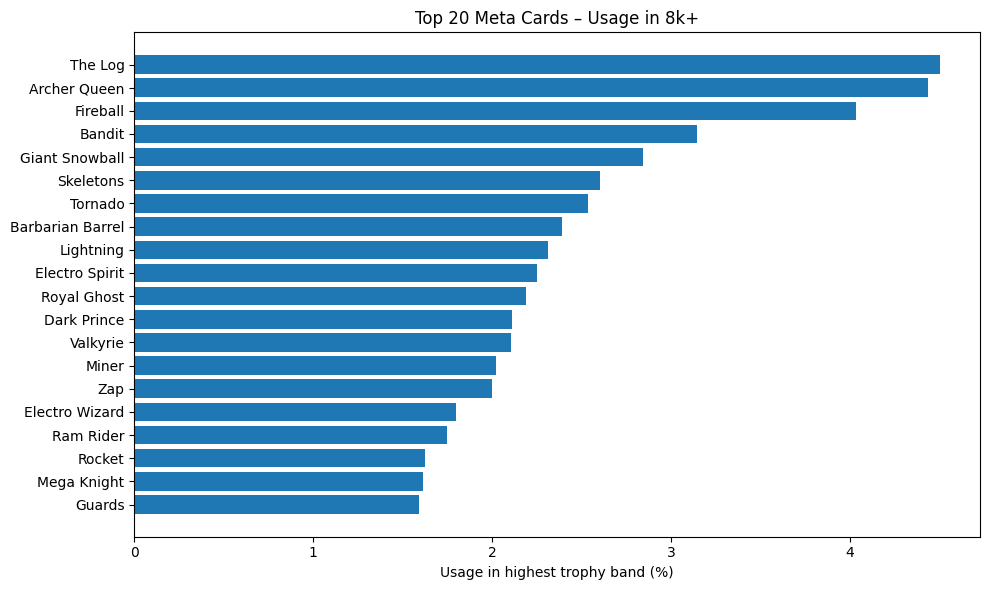

The second figure shows how usage changes across all bands for these meta cards. Two common formats:

Heatmap:

- Rows: cards from top_meta
- Columns: trophy bands (<5k, 5k–6k, 6k–7k, 7k–8k, 8k+)
- Cell color: usage_pct (lighter = more common)

This makes it easy to see:

- Risers: rows that get lighter as you move to the right (higher bands).
- Fallers: rows that get darker at the high end.
- Stable cards: rows that are similarly shaded across all bands.

Line plots:

- x-axis: trophy band (ordered)
- y-axis: usage percentage
- One line per card (for a few selected cards)

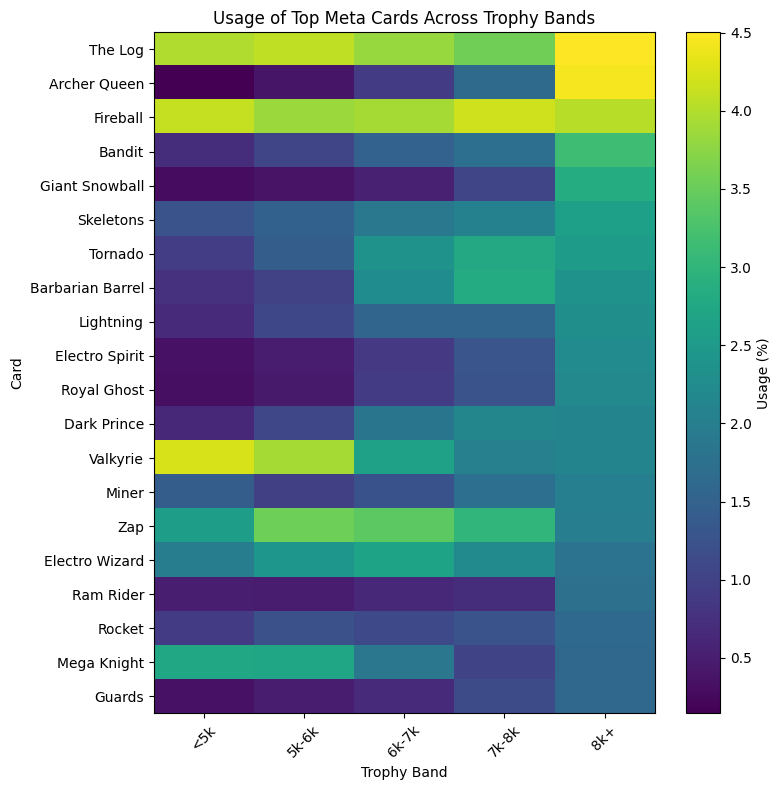

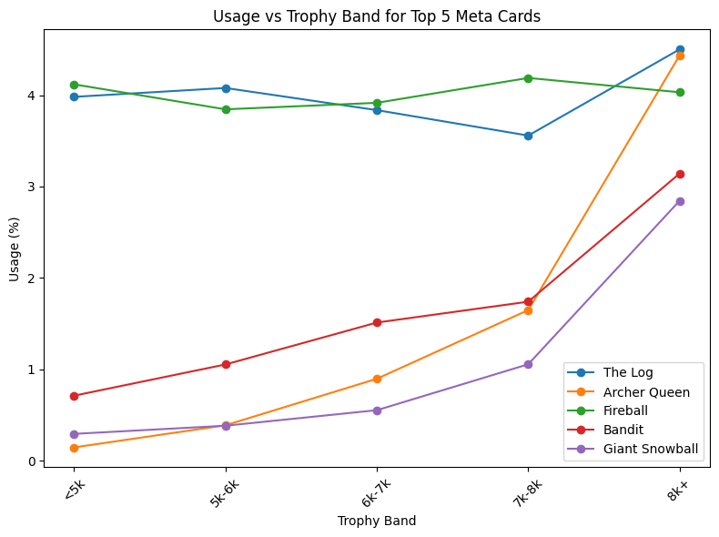

| trophy_band card | <5k | 5k-6k | 6k-7k | 7k-8k | 8k+ | usage_low | usage_high | delta_usage |
| --- | --- | --- | --- | --- | --- | --- | --- | --- |
| The Log | 0.039816 | 0.040788 | 0.038364 | 0.035578 | 0.045018 | 0.039816 | 0.045018 | 0.005202 |
| Archer Queen | 0.001443 | 0.003866 | 0.008954 | 0.016474 | 0.044361 | 0.001443 | 0.044361 | 0.042918 |
| Fireball | 0.041186 | 0.038451 | 0.039164 | 0.041886 | 0.040319 | 0.041186 | 0.040319 | -0.000866 |
| Bandit | 0.007105 | 0.010523 | 0.015110 | 0.017395 | 0.031427 | 0.007105 | 0.031427 | 0.024322 |
| Giant Snowball | 0.002923 | 0.003815 | 0.005516 | 0.010542 | 0.028446 | 0.002923 | 0.028446 | 0.025523 |
| Skeletons | 0.012581 | 0.014948 | 0.018943 | 0.020580 | 0.026021 | 0.012581 | 0.026021 | 0.013439 |
| Tornado | 0.009325 | 0.014367 | 0.023592 | 0.027747 | 0.025364 | 0.009325 | 0.025364 | 0.016039 |
| Barbarian Barrel | 0.007586 | 0.009849 | 0.022711 | 0.028315 | 0.023899 | 0.007586 | 0.023899 | 0.016313 |
| Lightning | 0.006550 | 0.010920 | 0.015651 | 0.015657 | 0.023141 | 0.006550 | 0.023141 | 0.016591 |
| Electro Spirit | 0.003552 | 0.004810 | 0.008722 | 0.013001 | 0.022484 | 0.003552 | 0.022484 | 0.018931 |
| Royal Ghost | 0.003145 | 0.004647 | 0.008955 | 0.012657 | 0.021878 | 0.003145 | 0.021878 | 0.018732 |
| Dark Prince | 0.006476 | 0.010786 | 0.018354 | 0.021373 | 0.021120 | 0.006476 | 0.021120 | 0.014644 |
| Valkyrie | 0.042296 | 0.039068 | 0.026341 | 0.020490 | 0.021069 | 0.042296 | 0.021069 | -0.021227 |
| Miner | 0.014247 | 0.009703 | 0.012373 | 0.017308 | 0.020210 | 0.014247 | 0.020210 | 0.005964 |
| Zap | 0.025940 | 0.035335 | 0.034087 | 0.030078 | 0.020008 | 0.025940 | 0.020008 | -0.005932 |
| Electro Wizard | 0.019760 | 0.024415 | 0.026753 | 0.022280 | 0.017987 | 0.019760 | 0.017987 | -0.001773 |
| Ram Rider | 0.005144 | 0.004814 | 0.006243 | 0.007146 | 0.017482 | 0.005144 | 0.017482 | 0.012338 |
| Rocket | 0.009177 | 0.012319 | 0.010986 | 0.012513 | 0.016269 | 0.009177 | 0.016269 | 0.007092 |
| Mega Knight | 0.027346 | 0.027266 | 0.018745 | 0.010441 | 0.016118 | 0.027346 | 0.016118 | -0.011228 |
| Guards | 0.003589 | 0.004925 | 0.006734 | 0.011344 | 0.015916 | 0.003589 | 0.015916 | 0.012326 |

#### Answer to Question 4 and Interpretation

Based on the usage-by-band analysis, the answer is:

- Yes. There is clear meta bias: some cards are used substantially more at high trophies than at low trophies, while others fade out as trophy level increases.

Key points from the analysis:

- Top-ladder decks are not just random samples of the overall card pool. Certain cards are significantly overrepresented in the highest trophy band, indicating a clear high-tier meta.
- Some cards “scale with skill.” Cards with large positive delta_usage are much more common among high-trophy players than low-trophy players. This suggests they:
  - fit better into advanced strategies,
  - or are more effective when piloted by experienced players.
- Some cards are “low-ladder” options. Cards with negative delta_usage are more common at lower trophies and relatively rare at the top. These may be:
- easier to use or understand,
- or simply less viable in the fast, tightly optimized meta at higher levels.
- A group of “universal staples” exists. Some cards maintain high usage across all trophy bands with small delta_usage. These are consistent, flexible cards that are valued regardless of player level.

Real-life implications:

- For players, the results suggest that “what good players use” is not just flavor or personal taste; certain cards genuinely become more central as you climb. Studying these high-tier staples and risers can help players adjust their decks as they move up the ladder.
- For game designers, the presence of strong meta concentration at high trophies is expected, but if a few cards dominate too heavily in usage_high, it may be worth examining whether they are too efficient or crowding out alternatives.
- For balance and strategic diversity, the analysis indicates that while many cards see some play, the high-trophy meta is more selective, favoring a subset of cards that synergize well with top-level strategies.

## 7) Recommendations to Stakeholders

### a) Recommendations 1

Action Items

For players:

- Trophy difference does influence win rate, but only modestly. Even a 100–300 trophy advantage yields only a small shift in expected win probability.
- Players should not rely solely on trophy count when deciding how confident they should feel about a matchup; deck choice and play are more impactful.

For competitive scene organizers and analysts:

- Use trophy difference cautiously when predicting match outcomes-it should not be treated as a decisive factor.
- When commentating or preparing match previews, emphasize deck matchup and player tendencies over raw trophy totals.
- In tournament seeding, avoid assuming higher-ladder players inherently outperform others; the effect size is small.

Limitations

- The analysis uses only trophy difference and does not account for:
  - Player skill variability not captured by trophies
  - Deck matchup effects
  - Card levels (the dataset does not include level data)
- Logistic regression assumes a smooth, linear log-odds relationship, which may miss non-linear effects (e.g., diminishing returns at high differences).

How to Address Limitations

- Incorporate additional player-specific variables (card levels, historical win rate, season peak).
- Try non-linear models (random forests, GAMs) to check whether the relationship deviates from a logistic curve.
- Analyze specific deck archetype matchups to isolate the effect of trophy difference within comparable contexts.

### b) Recommendations 2

Action Items

For players:

- Most cards perform near the 50% baseline, suggesting that deck structure and synergy matter more than individual card strength.
- Players should prioritize learning archetypes and matchups rather than chasing individual “broken” cards.

For game designers:

- The narrow win-rate distribution indicates generally healthy card balance.
- Cards consistently above or below 50% (even by a few percent) may warrant monitoring for future balance passes.

For competitive scene organizers and analysts:

- Use card usage + win rate to explain why certain archetypes thrive in tournaments, rather than implying a single “OP” card drives outcomes.
- When reviewing patch notes or analyzing meta shifts, pair-level or deck-level trends are more insightful than individual card metrics.

Limitations

- The analysis does not account for:
  - Deck context (a card might be strong only in certain archetypes)
  - Player skill differences
  - Card levels (important for ladder play)
- Win rate is aggregated across all decks and matchups, which can dilute or hide situational strengths.

How to Address Limitations

- Stratify analysis by deck archetype or playstyle rather than treating all decks as comparable.
- Compare cards within trophy brackets to reduce skill/experience confounding.
- Include card-level data for more accurate assessment of performance.

### c) Recommendations 3

Action Items

For players:

- The top-performing card pairs show genuine synergy; incorporating these combinations can meaningfully increase deck success.
- Mid-usage/high-win-rate pairs represent underrated synergies that could be powerful in niche deck types.

For game designers:

- Consistently high-performing pairs should be monitored, as strong synergies can create over-centralization or reduce deck diversity.
- Cards that underperform as pairs might benefit from slight buffs or reworks to improve combinational viability.

For competitive scene organizers and analysts:

- Highlight strong synergies as core pillars of successful archetypes in competitive play.
- Use synergy data to explain why certain decks dominate tournaments (e.g., “This deck’s main strength comes from the X–Y synergy”).
- Incorporate pair-performance metrics into pre-match analysis to contextualize why certain players choose specific decks.
- When evaluating patch effects, focus on whether synergy structures change, not just individual card win rates.

Limitations

- Pair strength is influenced by:
  - The overall deck archetype surrounding the pair
  - Player familiarity with that archetype
  - Matchup distribution across pair types
- High usage may reflect popularity, not necessarily optimal strength.
- Low-usage pair win rates have wider confidence intervals, reducing reliability.

How to Address Limitations

- Incorporate archetype clustering to contextualize pair performance within deck families.
- Weight pair effectiveness by matchup difficulty to avoid inflating easy archetypes.
- Investigate three-card combinations or higher-order synergies to evaluate more complex deck structures.

### d) Recommendations 4

Action Items

For players:

- The analysis clearly shows certain cards increase dramatically in usage at high trophies.
- Adapting to the high-ladder meta, by learning these cards or preparing counters to them, can improve competitive performance.

For game designers:

- High-trophy “spikes” in usage suggest these cards may be dominant in advanced play.
- Cards with sharp decreases in usage at high trophies may be outclassed, indicating possible balance adjustments.

For competitive scene organizers and analysts:

- Use trophy-stratified usage data to explain why the competitive meta differs from ladder play.
- Identify and communicate the “true tournament staples”-cards that remain strong even at the highest trophy range.
- When producing meta reports or pre-event analysis, rely on trophy-band data to show how strategies evolve at high skill levels.
- After balance updates, track usage shifts across bands to provide data-driven patch commentary.

Limitations

- Usage does not necessarily equal strength; some cards may simply be popular or fashionable.
- Trophy bands are coarse categories; player skill differences within a band can still be significant.
- No information is available on card levels, matchups, or deck composition in Q4’s usage-only view.

How to Address Limitations

- Combine usage analysis with win rate in each trophy band to estimate whether cards are strong or simply popular.
- Use finer-grained trophy segmentation or ELO-like rating systems to better capture skill.
- Incorporate deck-level clustering to examine which archetypes drive usage trends.

## 8) Conclusion

Taken together, the analyses from Questions 1–4 reveal that success in Clash Royale cannot be attributed to any single factor: neither raw trophy count, nor isolated card strength, nor even individual synergies fully determine outcomes on their own. Instead, the game’s competitive landscape emerges from the interaction of player skill, strategic deck-building, and meta evolution. The modest predictive power of trophy difference suggests that matchmaking keeps games reasonably balanced but also highlights that trophies alone are an incomplete measure of competitive capability. Similarly, the card-level analysis shows a remarkably narrow spread in individual card win rates, emphasizing that Clash Royale’s balance philosophy prevents single cards from dominating the meta on their own. Yet when we shift the focus to pairs of cards, clear synergies emerge, showing that meaningful advantages arise when cards are combined within coherent strategies rather than examined in isolation. Finally, the trophy-stratified usage analysis demonstrates that high-level players gravitate toward a distinct subset of cards, revealing that the meta becomes more specialized as skill increases, even when individual card win rates remain relatively flat.

Viewed together, these findings suggest that competitive success in Clash Royale is driven by structure, not pieces. It is not individual cards or player trophies that matter most, but how cards work together in decks, how those decks operate within the meta, and how skilled players leverage those structures at different trophy levels. For players, this means improvement comes from understanding archetypes, synergies, and matchup dynamics more than from seeking out “strongest cards.” For game designers, the results affirm broad card-level balance while highlighting the importance of monitoring synergy-driven patterns and high-ladder usage concentration.